# Group 25 :Assignment 2.5

Melissa Tan Joy Li 200249191 | Zhuoyang Li 480164337 | Biji George 470346121 | Joseph Tagudin 470542996 | Sergio Kulikovsky 480322960

31 十月, 2018

> STAT5003 Computational Statistic Final Project 1

# 1 Introduction

Below is the problem statement issued from the precisionFDA website that forms part of this assignment.

“In biomedical research, sample mislabeling (accidental swapping of patient samples) or data mislabeling (accidental swapping of patient omics data) has been a long-standing problem that contributes to irreproducible results and invalid conclusions. These problems are particularly prevalent in large scale multi-omics studies, in which multiple different omics experiments are carried out at different time periods and/or in different labs. Human errors could arise during sample transferring, sample tracking, large-scale data generation, and data sharing/management. Thus, there is a pressing need to identify and correct sample and data mislabeling events to ensure the right data for the right patient. Simultaneous use of multiple types of omics platforms to characterize a large set of biological samples, as utilized in The Cancer Genome Atlas (TCGA) and the Clinical Proteomic Tumor Analysis Consortium (CPTAC) projects, has been demonstrated as a powerful approach to understanding the molecular basis of diseases and speeding the translation of new discoveries to patient care. Comprehensive multi-omics data obtained on the same patient sample can also add value in pinpointing and correcting mislabeling problems that can be encountered in the process. The FDA and NCI-CPTAC have joined forces to launch this challenge to encourage the development and evaluation of computational algorithms that can accurately detect and correct mislabeled samples using rich multi-omics datasets (Boja et al. 2018)

Paired proteomics data were generated for each of the 162 tumor samples. Protein quantification was based on spectral counting and mRNA quantification was based on Fragments Per Kilobase of transcript per Million mapped reads (FPKM). For both proteomics and RNA-Seq data, genes with more than 50% missing values were removed, except for genes located in X or Y chromosomes, which were retained even if they were missed in more than 50% of the samples. The proteomics data was then normalized using quantile normalization followed by batch correction using ComBat, whereas the RNA-Seq data was normalized using the trimmed mean of M-values normalization method (TMM) followed by batch correction using ComBat“”

# 2 Data Preparation

- **train|test_cli** - Contains clinical information such as gender and Microsatellite instability (MSI) status for the 80 training samples.
- **train|test_pro** - Proteomics data from the 80 training samples. Each row represents a protein and each column represents a training sample.
- **train|test_key** - Mislabelling information for the training samples. 0 indicates match i.e. clinical and proteomics data are from the same sample. 1 indicates that are not from the sample.

The gender & msi columns in the train_cli and test_cli.csv are combined and stored as factor.

```r
library(tidyverse) # for tidy data analysis
library(readr)     # for fast reading of input files
library(mice)      # mice package for Multivariate Imputation by Chained Equations (MICE)

# --------------------------------
# Load Data
# --------------------------------
train_cli <- read.table("train_cli.tsv", header=T, sep = "\t", stringsAsFactors=T)
train_pro <- read.table("train_pro.tsv", header=T, sep = "\t", stringsAsFactors=T)
train_key <- read.table("sum_tab_1.csv", header=T, sep = ",", stringsAsFactors=T)


test_cli <- read.csv("test_cli.tsv", header=T, sep = "\t", stringsAsFactors=T)
test_pro <- read.csv("test_pro.tsv", header=T, sep = "\t", stringsAsFactors=T)


# --------------------------------
# Transpose _pro files
# --------------------------------
train_pro <- as.data.frame(t(train_pro))
test_pro <- as.data.frame(t(test_pro))
train_pro[1:5,(ncol(train_pro)-5):ncol(train_pro)]
```

|  | ZNF638 | ZNF706 | ZPR1 | ZW10 | ZYX | ZZEF1 |
| --- | --- | --- | --- | --- | --- | --- |
| Training_1 | 1.007971 | 1.005565 | 1.016313 | 1.859706 | 3.834986 | NA |
| Training_2 | 1.516790 | 1.009703 | NA | 1.465056 | 4.156957 | NA |
| Training_3 | NA | 1.009703 | 1.019879 | 1.932920 | 4.303349 | NA |
| Training_4 | 1.024392 | NA | 1.589198 | 1.569086 | 5.218254 | NA |
| Training_5 | 1.134580 | 1.120853 | 1.129109 | 1.205099 | 4.190499 | 1.756951 |

```r
test_pro[1:5,(ncol(test_pro)-5):ncol(test_pro)]
```

|  | ZNF638 | ZNF706 | ZPR1 | ZW10 | ZYX | ZZEF1 |
| --- | --- | --- | --- | --- | --- | --- |
| Testing_1 | NA | 1.058798 | 1.848274 | 2.565798 | 3.597116 | 1.636396 |
| Testing_2 | 1.733361 | NA | 0.997150 | 2.265862 | 3.967766 | 1.802938 |
| Testing_3 | 1.126579 | NA | 1.120824 | 2.944166 | 3.779964 | 1.756282 |
| Testing_4 | 1.081373 | 1.780610 | 1.074043 | NA | 3.918465 | NA |
| Testing_5 | NA | 1.721321 | NA | 1.795269 | 3.535849 | NA |

```r
# --------------------------------
# Clean Column Names
# --------------------------------
# Replace punctuation from column to dot. Eg column C15orf38-AP3S2 throw issue because it contains hyphen in the name.
colnames(train_pro) <- sub("[[:punct:]]", ".", colnames(train_pro))
colnames(test_pro) <- sub("[[:punct:]]", ".", colnames(test_pro))


# ---------------------------------------------------------------------
# Feature Engineering - Combine gender & msi into a single column
# ---------------------------------------------------------------------
train_cli$class <- as.factor(paste(train_cli$gender , train_cli$msi))
train_cli$mismatch <- factor(train_key$mismatch, levels = c(0, 1), labels = c("0-Match", "1-Mismatch"))

test_cli$class <- as.factor(paste(test_cli$gender , test_cli$msi))
```

# 3 Data Preprocessing

The following were provided * 10% labelling errors were introduced to the samples for the proteomics data. and 5% to the clinical information table. Sample labelling errors were not shared across different types of data (i.e., for each sample, a mislabelling error only occurs in, at most, one type of data), so that all three data types can be used to identify the sources of the error. * For proteomics there are three error types: * Sample duplication (B to A’, where A’ is a duplicate of A), sample swapping (A to B and B to A), * Sample shifting (A to B, B to C, and C to D). * Duplicated proteomic samples came from technical replications (outputs from independent proteomics experiments of the same biological samples). The swapped samples were required to have different gender or MSI status. * For clinical data, swapping (A to B and B to A) between gender inconsistent samples.

## 3.1 Data Imputation

Data imputation is done to remove or substitute missing values in the dataset. Missing data has to be addressed, otherwise it will bring in a lot of vagueness and undermine the validity the data. In our project, we combined both the training and test set for data imputation to avoid variance in the features being imputed. After the imputation, the samples were separated, back again, to the training and testing samples respectively. For e.g. in the Proteomic training dataset, feature “ATP7A” has 79 out of 80 rows as NA. As such, those features that had more than 90% missing data had been removed before the data imputation was done. [2,3]

In the following sub-sections, the single imputation approaches taken for this project are described, and only the best result of training the imputed data was further taken for evaluating the prediction models. The KNN algorithm was used to benchmark the results for each of the imputation approaches, and further selection, by evaluating the metrics such as the F1 score, accuracy and confusion matrix.

Note: MICE – Multiple Imputation by Chained Equations (MICE) is an iterative algorithm based on chained equations that used an imputation model specified separately for each variable and involving the other variables as predictors. This approach was abandoned as it was resource intensive and the proteomic training dataset had 4,118 features to begin with.

### 3.1.1 Summary

Analyse the dataset to see how much NA we are dealing with.

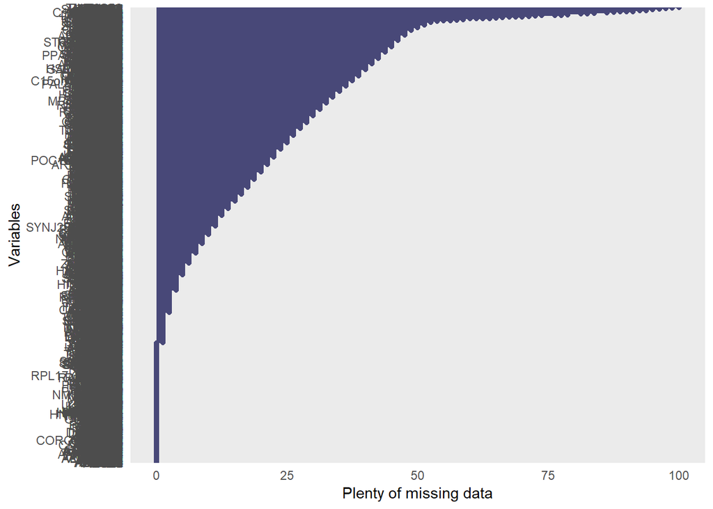

```r
library(ggplot2)
library(naniar)
gg_miss_var(train_pro , show_pct = TRUE) + labs(y = "Plenty of missing data")
```

```r
# -------------------------------------------------------------------------------
# Combine train_pro & test_pro to get consistent columns before dropping NA columns
# -------------------------------------------------------------------------------
# Retain those column that has less than 90% NA. The others will be dropped. This will bring the variable count to 160x4085
mega_pro90 <- rbind(train_pro, test_pro) %>%
                .[lapply(., function(x) sum(is.na(x)) / length(x) ) < 0.9]
```

### 3.1.2 Mean Imputation

Mean imputation consists of replacing the missing data for a given feature by the mean of all known values of that feature. The Hmisc R package was used for this imputation. The main advantages of mean imputation are that it is simple to apply and understand, it does not reduce the sample size in any form and, if the missing values are completely random, then this imputation approach is totally unbiased. Disadvantages are that it can be biased towards the multivariate estimates such as correlation or regression coefficients as well as towards the standard variance and error. [3]

As each chuck are run against a set of files, code to upsampled the data is also included to reduce file I/O.

```r
library(data.table)
library(Hmisc)
library(caret)
library(impute)

# --------------------------------------------
# Mean imputation
# --------------------------------------------
imp <- as.matrix(impute(rbind(train_pro, test_pro) , mean))
write.csv(imp[1:80,] , file=paste("Mean_imp_train.csv"))
write.csv(imp[81:160,] , file=paste("Mean_imp_test.csv"))

# ----------------------------------------------
# run knn against Mean imputation
# ----------------------------------------------
filenames = 'Mean_imp_train.csv'
train_set <-  read.table(filenames, header=T, sep = ",", stringsAsFactors=T, row.names = 1) %>%
                merge(., train_cli[,c(1,4,5)], by.x=0, by.y='sample', all=TRUE)
rownames(train_set) <- train_set$Row.names
train_set$Row.names <- NULL
train_set_mean <- subset(train_set, mismatch %in% "0-Match")
classColNum <- grep("class",names(train_set_mean))
mismatchColNum <- grep("mismatch",names(train_set_mean))
# train_set[1:15,(ncol(train_set)-5):ncol(train_set)]

set.seed(1)
index <- createDataPartition(train_set_mean$class, p = 0.7, list = FALSE)
train_data <- train_set_mean[ index, -mismatchColNum]
test_data  <- train_set_mean[-index, ]

set.seed(1)
ctrl <- trainControl(method = "repeatedcv", number=10, verboseIter=FALSE, sampling=NULL)
model_mean <- train(class~., data=train_data, method = "knn", preProcess = c("scale", "center"), trControl=ctrl )
pred <- predict(model_mean, test_data)
cm_mean <- confusionMatrix(pred, test_data$class)

# ----------------------------------------------
# run knn against Mean imputation & upsampled
# ----------------------------------------------
set.seed(1)
ctrl$sampling <-  "up"
model_mean_up <- train(class~., data=train_data, method = "knn", preProcess = c("scale", "center"), trControl=ctrl )
pred <- predict(model_mean_up, test_data)
cm_mean_up <- confusionMatrix(pred, test_data$class)
```

### 3.1.3 Median Imputation

Median imputation consists of replacing the missing data for a given feature by the median of all known values of that feature. The Hmisc R package was used for this imputation. This approach has similar advantages and disadvantages as the mean imputation. It has one major advantage over mean imputation is that it is preferable when the dataset is skewed, and this approach is outlier robust. [4]

```r
# --------------------------------------------
# Median imputation
# --------------------------------------------
imp <- as.matrix(impute(rbind(train_pro, test_pro) , median))
write.csv(imp[1:80,] , file=paste("Median_imp_train.csv"))
write.csv(imp[81:160,] , file=paste("Median_imp_test.csv"))

# --------------------------------------------
# run knn against median imputation
# --------------------------------------------
filenames = 'Median_imp_train.csv'
train_set <-  read.table(filenames, header=T, sep = ",", stringsAsFactors=T, row.names = 1) %>%
                merge(., train_cli[,c(1,4,5)], by.x=0, by.y='sample', all=TRUE)

rownames(train_set) <- train_set$Row.names
train_set$Row.names <- NULL
train_set_median  <- subset(train_set, mismatch %in% "0-Match")
classColNum <- grep("class",names(train_set_median))
mismatchColNum <- grep("mismatch",names(train_set_median))

set.seed(1)
index <- createDataPartition(train_set_median$class, p = 0.7, list = FALSE)
train_data <- train_set_median[ index, -mismatchColNum]
test_data  <- train_set_median[-index, ]

set.seed(1)
ctrl <- trainControl(method = "repeatedcv", number=10, verboseIter=FALSE, sampling=NULL)
model_median <- train(class~., data=train_data, method = "knn", preProcess = c("scale", "center"), trControl=ctrl )
pred <- predict(model_median, test_data)
cm_median <- confusionMatrix(pred, test_data$class)

# ----------------------------------------------
# run knn against median imputation & upsampled
# ----------------------------------------------
set.seed(1)
ctrl$sampling <-  "up"
model_median_up <- train(class~., data=train_data, method = "knn", preProcess = c("scale", "center"), trControl=ctrl )
pred <- predict(model_median_up, test_data)
cm_median_up <- confusionMatrix(pred, test_data$class)
```

### 3.1.4 KNN-Imputation

The kNN imputation approach is based on the kNN algorithm. These values are obtained by using similarity-based methods that rely on distance metrics such as Euclidean distance, Jaccard similarity, Minkowski norm etc. They can be used to predict both discrete and continuous attributes. The main disadvantage of using kNN imputation is that it becomes time-consuming when analysing large datasets because it searches for similar instances throughout the dataset. Note that an important criterion while using kNN imputation is selecting the optimal value for the number of neighbours (k).

```r
#source("http://bioconductor.org/biocLite.R")
#biocLite("impute")
library(impute)
library(caret)

imp <-impute.knn(as.matrix(mega_pro90) ,k = 80, rowmax = 0.5, colmax = 0.9, maxp = 1500, rng.seed=362436069)
write.csv(imp$data[1:80,],file='knn_imp_train.csv')
write.csv(imp$data[81:160,],file='knn_imp_test.csv')

# -----------------------------------
# run knn against knn imputation
# -----------------------------------
filenames = 'knn_imp_train.csv'
train_set <-  read.table(filenames, header=T, sep = ",", stringsAsFactors=T, row.names = 1) %>%
                merge(., train_cli[,c(1,4,5)], by.x=0, by.y='sample', all=TRUE)
rownames(train_set) <- train_set$Row.names
train_set$Row.names <- NULL
train_set_knn <- subset(train_set, mismatch %in% "0-Match")
classColNum <- grep("class",names(train_set_knn))
mismatchColNum <- grep("mismatch",names(train_set_knn))

set.seed(1)
index <- createDataPartition(train_set_knn$class, p = 0.7, list = FALSE)
train_data <- train_set_knn[ index, -mismatchColNum]
test_data  <- train_set_knn[-index, ]

set.seed(1)
ctrl <- trainControl(method = "repeatedcv", number=10, verboseIter=FALSE, sampling=NULL)
model_knn <- train(class~., data=train_data, method = "knn", preProcess = c("scale", "center"), trControl=ctrl )
pred <- predict(model_knn, test_data)
cm_knn <- confusionMatrix(pred, test_data$class)

# ----------------------------------------------
# run knn against knn imputation & upsampled
# ----------------------------------------------
set.seed(1)
ctrl$sampling <-  "up"
model_knn_up <- train(class~., data=train_data, method = "knn", preProcess = c("scale", "center"), trControl=ctrl )
pred <- predict(model_knn_up, test_data)
cm_knn_up <- confusionMatrix(pred, test_data$class)
```

### 3.1.5 missMDA

missMDA performs principal component methods with missing values and is also used to impute data with PC methods. To achieve this goal, the missing values are predicted using the iterative PCA algorithm for a predefined number of dimensions. Then, PCA is performed on the imputed dataset. The single imputation step requires tuning of the number of dimensions used to impute the data.

This imputation approach takes quite a while to run. Therefore, this chunk was disabled and executed manually to generate a once-off csv file which was read-in directly for any future processing.

```r
library(missMDA)
#?estim_ncpPCA
#?imputePCA

# example ran using train_pro<05-80x3938. Takes about 1:29-1:43 mins
nb <- estim_ncpPCA(mega_pro90, method.cv = "Kfold", verbose = FALSE) # estimate the number of components from incomplete data
#(available methods include GCV to approximate CV)
nb$ncp #2


#plot(0:5, nb$criterion, xlab = "nb dim", ylab = "MSEP")
imp.train <- imputePCA(mega_pro90, ncp = nb$ncp) # iterativePCA algorithm
imp.train$completeObs[,1:5]

write.csv(as.matrix(imp.train$completeObs[1:80,]), file=paste("missMDA_imp_train.csv"))
write.csv(as.matrix(imp.train$completeObs[81:160,]), file=paste("missMDA_imp_test.csv"))
```

```r
# -----------------------------------
# run knn against MissMDA imputation
# -----------------------------------
filenames = 'missMDA_imp_train.csv'
train_set <-  read.table(filenames, header=T, sep = ",", stringsAsFactors=T, row.names = 1) %>%
                merge(., train_cli[,c(1,4,5)], by.x=0, by.y='sample', all=TRUE)
rownames(train_set) <- train_set$Row.names
train_set$Row.names <- NULL

# Filter for 0-Match record only
train_set_mda <- subset(train_set, mismatch %in% "0-Match")
classColNum <- grep("class",names(train_set_mda))
mismatchColNum <- grep("mismatch",names(train_set_mda))
# train_set[1:5,(ncol(train_set)-5):ncol(train_set)]

library(caret)
set.seed(1)
index <- createDataPartition(train_set_mda$class, p = 0.7, list = FALSE)
train_data <- train_set_mda[ index, -mismatchColNum]
test_data  <- train_set_mda[-index, ]

set.seed(1)
ctrl <- trainControl(method = "repeatedcv", number=10, verboseIter=FALSE, sampling=NULL)
model_mda <- train(class~., data=train_data, method = "knn", preProcess = c("scale", "center"), trControl=ctrl )
pred <- predict(model_mda, test_data)
cm_mda <- confusionMatrix(pred, test_data$class)

# ----------------------------------------------
# run knn against missmda imputation & upsampled
# ----------------------------------------------
set.seed(1)
ctrl$sampling <-  "up"
model_mda_up <- train(class~., data=train_data, method = "knn", preProcess = c("scale", "center"), trControl=ctrl )
pred <- predict(model_mda_up, test_data)
cm_mda_up <- confusionMatrix(pred, test_data$class)
```

### 3.1.6 Result

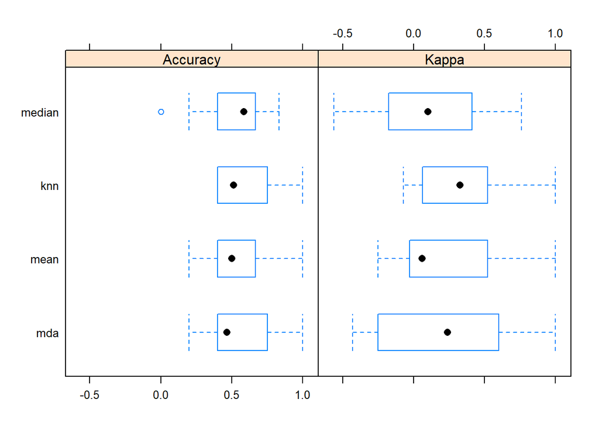

```r
models <- list(mean = model_mean ,median = model_median ,knn = model_knn ,mda = model_mda )
bwplot(resamples(models))
```

```r
for (name in names(models)) {
    model <- get(paste0("cm_", name))
    print(paste0("cm_", name))
    print(as.data.frame(model[["byClass"]][,c(1,2,5,6,7,11)]))
}
```

```
## [1] "cm_mean"
##                           Sensitivity Specificity Precision Recall
## Class: Female MSI-High            0.5   0.8823529 0.3333333    0.5
## Class: Female MSI-Low/MSS         0.9   0.6666667 0.7500000    0.9
## Class: Male MSI-High              1.0   1.0000000 1.0000000    1.0
## Class: Male MSI-Low/MSS           0.5   1.0000000 1.0000000    0.5
##                                  F1 Balanced Accuracy
## Class: Female MSI-High    0.4000000         0.6911765
## Class: Female MSI-Low/MSS 0.8181818         0.7833333
## Class: Male MSI-High      1.0000000         1.0000000
## Class: Male MSI-Low/MSS   0.6666667         0.7500000
## [1] "cm_median"
##                           Sensitivity Specificity Precision Recall
## Class: Female MSI-High            0.5   0.9411765 0.5000000    0.5
## Class: Female MSI-Low/MSS         0.9   0.5555556 0.6923077    0.9
## Class: Male MSI-High              0.0   1.0000000        NA    0.0
## Class: Male MSI-Low/MSS           0.5   0.9230769 0.7500000    0.5
##                                  F1 Balanced Accuracy
## Class: Female MSI-High    0.5000000         0.7205882
## Class: Female MSI-Low/MSS 0.7826087         0.7277778
## Class: Male MSI-High             NA         0.5000000
## Class: Male MSI-Low/MSS   0.6000000         0.7115385
## [1] "cm_knn"
##                           Sensitivity Specificity Precision    Recall
## Class: Female MSI-High      0.5000000   0.9411765 0.5000000 0.5000000
## Class: Female MSI-Low/MSS   0.8000000   0.6666667 0.7272727 0.8000000
## Class: Male MSI-High        0.0000000   1.0000000        NA 0.0000000
## Class: Male MSI-Low/MSS     0.6666667   0.8461538 0.6666667 0.6666667
##                                  F1 Balanced Accuracy
## Class: Female MSI-High    0.5000000         0.7205882
## Class: Female MSI-Low/MSS 0.7619048         0.7333333
## Class: Male MSI-High             NA         0.5000000
## Class: Male MSI-Low/MSS   0.6666667         0.7564103
## [1] "cm_mda"
##                           Sensitivity Specificity Precision    Recall
## Class: Female MSI-High      0.5000000   0.9411765 0.5000000 0.5000000
## Class: Female MSI-Low/MSS   0.9000000   0.4444444 0.6428571 0.9000000
## Class: Male MSI-High        0.0000000   1.0000000        NA 0.0000000
## Class: Male MSI-Low/MSS     0.3333333   0.9230769 0.6666667 0.3333333
##                                  F1 Balanced Accuracy
## Class: Female MSI-High    0.5000000         0.7205882
## Class: Female MSI-Low/MSS 0.7500000         0.6722222
## Class: Male MSI-High             NA         0.5000000
## Class: Male MSI-Low/MSS   0.4444444         0.6282051
```

## 3.2 Class Imbalance

In R, this problem can be tackled by using the weighted, or sampling, approach. For the project, we decided to go with up-sampling as the dataset only has 80 samples and it couldn’t be further reduced. Also, the model training to be done downstream only uses the labels that matched, which further brought the overall sample size down to only 68 samples.

In the up-sampling approach, it is vital that we do it only for the training set. Also, the approach is to sample, with replacements, to make the class distributions equal.

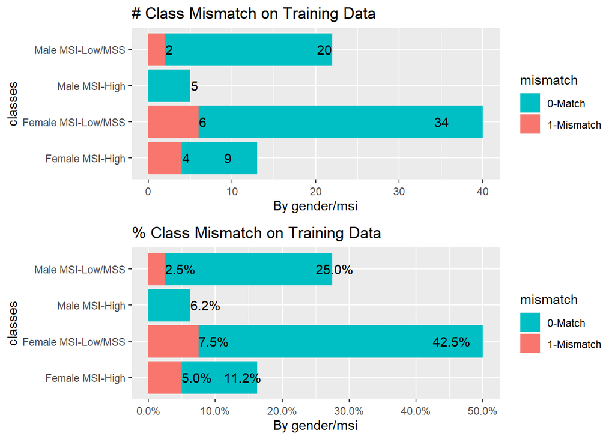

```r
library(ggplot2)
library(scales)
library(gridExtra)

train_set <- merge(train_pro, train_cli[,c(1,4,5)], by.x=0, by.y='sample', all=TRUE)
# train_set[1:5,(ncol(train_set)-5):ncol(train_set)]

g1 <- ggplot(train_set, aes(x = class, fill=mismatch)) +
    geom_bar(aes(y = (..count..))) +
    geom_text(aes(y =  ((..count..)) , label = ((..count..))) , stat = "count", vjust = 0.5, hjust=-0.1) +
    coord_flip() + # flip horizontal
    theme(axis.text.x = element_text(angle=0, vjust=0.6)) +
    labs(title = "# Class Mismatch on Training Data", y = "By gender/msi", x = "classes") +
    theme(legend.position="right") +
    scale_fill_manual(values=gr_pallete)

g2 <- ggplot(train_set, aes(x = class, fill=mismatch)) +
    geom_bar(aes(y = (..count..)/sum(..count..))) +
    geom_text(aes(y =  ((..count..)/sum(..count..)) , label = scales::percent((..count..)/sum(..count..))), stat = "count", vjust = 0.5, hjust=0) +
    coord_flip() + # flip horizontal
    theme(axis.text.x = element_text(angle=0, vjust=0.6)) +
    labs(title = "% Class Mismatch on Training Data", y = "By gender/msi", x = "classes") +
    scale_y_continuous(labels = percent) +
    scale_fill_manual(values=gr_pallete)

grid.arrange(g1,g2,nrow=2, ncol=1)
```

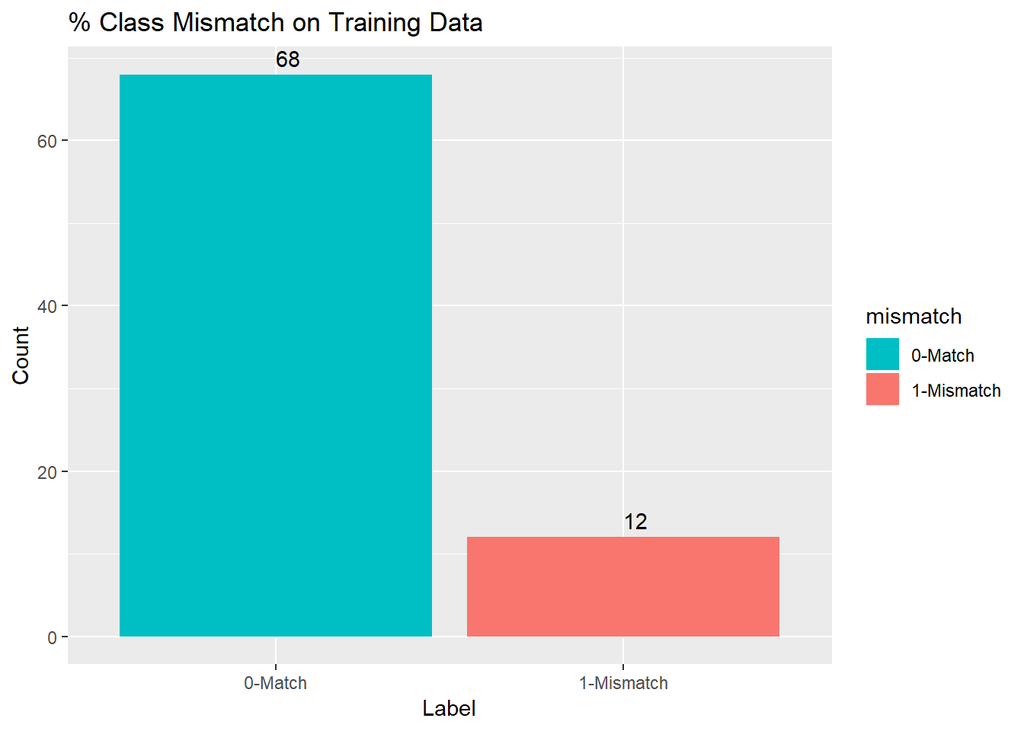

```r
rm(g1)
rm(g2)



# Response variable for classification
ggplot(train_set, aes(x = mismatch, fill = mismatch)) +
    geom_bar(aes(y = (..count..))) +
    geom_text(aes(y =  ((..count..)) , label = ((..count..))) , stat = "count", vjust = -0.5, hjust=0) +
    labs(title = "% Class Mismatch on Training Data", y = "Count", x = "Label") +
    scale_fill_manual(values=gr_pallete)
```

### 3.2.1 Result

> Result seems worst off

The initial preliminary analysis is slotted in here to show that by upsampling the data, we have overfitted the data. Performance against test was poor.

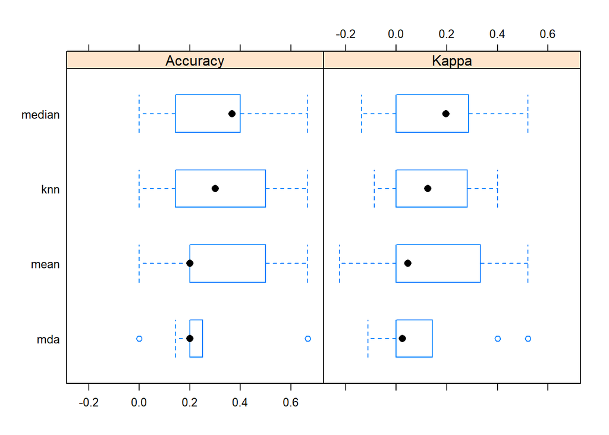

```r
models <- list(mean=model_mean_up, median=model_median_up, knn=model_knn_up, mda=model_mda_up)
bwplot(resamples(models))
```

```r
for (name in names(models)) {
    model <- get(paste0("cm_", name))
    print(paste0("cm_", name))
    print(as.data.frame(model[["byClass"]][,c(1,2,5,6,7,11)]))
}
```

```
## [1] "cm_mean"
##                           Sensitivity Specificity Precision Recall
## Class: Female MSI-High            0.5   0.8823529 0.3333333    0.5
## Class: Female MSI-Low/MSS         0.9   0.6666667 0.7500000    0.9
## Class: Male MSI-High              1.0   1.0000000 1.0000000    1.0
## Class: Male MSI-Low/MSS           0.5   1.0000000 1.0000000    0.5
##                                  F1 Balanced Accuracy
## Class: Female MSI-High    0.4000000         0.6911765
## Class: Female MSI-Low/MSS 0.8181818         0.7833333
## Class: Male MSI-High      1.0000000         1.0000000
## Class: Male MSI-Low/MSS   0.6666667         0.7500000
## [1] "cm_median"
##                           Sensitivity Specificity Precision Recall
## Class: Female MSI-High            0.5   0.9411765 0.5000000    0.5
## Class: Female MSI-Low/MSS         0.9   0.5555556 0.6923077    0.9
## Class: Male MSI-High              0.0   1.0000000        NA    0.0
## Class: Male MSI-Low/MSS           0.5   0.9230769 0.7500000    0.5
##                                  F1 Balanced Accuracy
## Class: Female MSI-High    0.5000000         0.7205882
## Class: Female MSI-Low/MSS 0.7826087         0.7277778
## Class: Male MSI-High             NA         0.5000000
## Class: Male MSI-Low/MSS   0.6000000         0.7115385
## [1] "cm_knn"
##                           Sensitivity Specificity Precision    Recall
## Class: Female MSI-High      0.5000000   0.9411765 0.5000000 0.5000000
## Class: Female MSI-Low/MSS   0.8000000   0.6666667 0.7272727 0.8000000
## Class: Male MSI-High        0.0000000   1.0000000        NA 0.0000000
## Class: Male MSI-Low/MSS     0.6666667   0.8461538 0.6666667 0.6666667
##                                  F1 Balanced Accuracy
## Class: Female MSI-High    0.5000000         0.7205882
## Class: Female MSI-Low/MSS 0.7619048         0.7333333
## Class: Male MSI-High             NA         0.5000000
## Class: Male MSI-Low/MSS   0.6666667         0.7564103
## [1] "cm_mda"
##                           Sensitivity Specificity Precision    Recall
## Class: Female MSI-High      0.5000000   0.9411765 0.5000000 0.5000000
## Class: Female MSI-Low/MSS   0.9000000   0.4444444 0.6428571 0.9000000
## Class: Male MSI-High        0.0000000   1.0000000        NA 0.0000000
## Class: Male MSI-Low/MSS     0.3333333   0.9230769 0.6666667 0.3333333
##                                  F1 Balanced Accuracy
## Class: Female MSI-High    0.5000000         0.7205882
## Class: Female MSI-Low/MSS 0.7500000         0.6722222
## Class: Male MSI-High             NA         0.5000000
## Class: Male MSI-Low/MSS   0.4444444         0.6282051
```

```r
filenames = 'knn_imp_test.csv'
testX <-  read.table(filenames, header=T, sep = ",", stringsAsFactors=T, row.names = 1 )
testY <-  test_cli$class

# confusion matrix based on training data
cm_knn
```

```
## Confusion Matrix and Statistics
##
##                     Reference
## Prediction           Female MSI-High Female MSI-Low/MSS Male MSI-High
##   Female MSI-High                  1                  0             1
##   Female MSI-Low/MSS               1                  8             0
##   Male MSI-High                    0                  0             0
##   Male MSI-Low/MSS                 0                  2             0
##                     Reference
## Prediction           Male MSI-Low/MSS
##   Female MSI-High                   0
##   Female MSI-Low/MSS                2
##   Male MSI-High                     0
##   Male MSI-Low/MSS                  4
##
## Overall Statistics
##
##                Accuracy : 0.6842
##                  95% CI : (0.4345, 0.8742)
##     No Information Rate : 0.5263
##     P-Value [Acc > NIR] : 0.1248
##
##                   Kappa : 0.4597
##  Mcnemar's Test P-Value : NA
##
## Statistics by Class:
##
##                      Class: Female MSI-High Class: Female MSI-Low/MSS
## Sensitivity                         0.50000                    0.8000
## Specificity                         0.94118                    0.6667
## Pos Pred Value                      0.50000                    0.7273
## Neg Pred Value                      0.94118                    0.7500
## Prevalence                          0.10526                    0.5263
## Detection Rate                      0.05263                    0.4211
## Detection Prevalence                0.10526                    0.5789
## Balanced Accuracy                   0.72059                    0.7333
##                      Class: Male MSI-High Class: Male MSI-Low/MSS
## Sensitivity                       0.00000                  0.6667
## Specificity                       1.00000                  0.8462
## Pos Pred Value                        NaN                  0.6667
## Neg Pred Value                    0.94737                  0.8462
## Prevalence                        0.05263                  0.3158
## Detection Rate                    0.00000                  0.2105
## Detection Prevalence              0.00000                  0.3158
## Balanced Accuracy                 0.50000                  0.7564
```

```r
# confusion matrix for upsampled using train
cm_knn_up
```

```
## Confusion Matrix and Statistics
##
##                     Reference
## Prediction           Female MSI-High Female MSI-Low/MSS Male MSI-High
##   Female MSI-High                  1                  1             0
##   Female MSI-Low/MSS               0                  6             0
##   Male MSI-High                    1                  0             1
##   Male MSI-Low/MSS                 0                  3             0
##                     Reference
## Prediction           Male MSI-Low/MSS
##   Female MSI-High                   1
##   Female MSI-Low/MSS                0
##   Male MSI-High                     2
##   Male MSI-Low/MSS                  3
##
## Overall Statistics
##
##                Accuracy : 0.5789
##                  95% CI : (0.335, 0.7975)
##     No Information Rate : 0.5263
##     P-Value [Acc > NIR] : 0.4111
##
##                   Kappa : 0.4039
##  Mcnemar's Test P-Value : NA
##
## Statistics by Class:
##
##                      Class: Female MSI-High Class: Female MSI-Low/MSS
## Sensitivity                         0.50000                    0.6000
## Specificity                         0.88235                    1.0000
## Pos Pred Value                      0.33333                    1.0000
## Neg Pred Value                      0.93750                    0.6923
## Prevalence                          0.10526                    0.5263
## Detection Rate                      0.05263                    0.3158
## Detection Prevalence                0.15789                    0.3158
## Balanced Accuracy                   0.69118                    0.8000
##                      Class: Male MSI-High Class: Male MSI-Low/MSS
## Sensitivity                       1.00000                  0.5000
## Specificity                       0.83333                  0.7692
## Pos Pred Value                    0.25000                  0.5000
## Neg Pred Value                    1.00000                  0.7692
## Prevalence                        0.05263                  0.3158
## Detection Rate                    0.05263                  0.1579
## Detection Prevalence              0.21053                  0.3158
## Balanced Accuracy                 0.91667                  0.6346
```

```r
# confusion matrix
pred <- predict(model_knn, testX)
confusionMatrix(pred, testY)
```

```
## Confusion Matrix and Statistics
##
##                     Reference
## Prediction           Female MSI-High Female MSI-Low/MSS Male MSI-High
##   Female MSI-High                  3                  2             4
##   Female MSI-Low/MSS               0                 11             3
##   Male MSI-High                    0                  0             0
##   Male MSI-Low/MSS                 3                 12             1
##                     Reference
## Prediction           Male MSI-Low/MSS
##   Female MSI-High                   2
##   Female MSI-Low/MSS               21
##   Male MSI-High                     1
##   Male MSI-Low/MSS                 17
##
## Overall Statistics
##
##                Accuracy : 0.3875
##                  95% CI : (0.2806, 0.503)
##     No Information Rate : 0.5125
##     P-Value [Acc > NIR] : 0.99075
##
##                   Kappa : 0.0434
##  Mcnemar's Test P-Value : 0.07013
##
## Statistics by Class:
##
##                      Class: Female MSI-High Class: Female MSI-Low/MSS
## Sensitivity                          0.5000                    0.4400
## Specificity                          0.8919                    0.5636
## Pos Pred Value                       0.2727                    0.3143
## Neg Pred Value                       0.9565                    0.6889
## Prevalence                           0.0750                    0.3125
## Detection Rate                       0.0375                    0.1375
## Detection Prevalence                 0.1375                    0.4375
## Balanced Accuracy                    0.6959                    0.5018
##                      Class: Male MSI-High Class: Male MSI-Low/MSS
## Sensitivity                        0.0000                  0.4146
## Specificity                        0.9861                  0.5897
## Pos Pred Value                     0.0000                  0.5152
## Neg Pred Value                     0.8987                  0.4894
## Prevalence                         0.1000                  0.5125
## Detection Rate                     0.0000                  0.2125
## Detection Prevalence               0.0125                  0.4125
## Balanced Accuracy                  0.4931                  0.5022
```

```r
# confusion matrix upsampled
pred <- predict(model_knn_up, testX)
confusionMatrix(pred, testY)
```

```
## Confusion Matrix and Statistics
##
##                     Reference
## Prediction           Female MSI-High Female MSI-Low/MSS Male MSI-High
##   Female MSI-High                  2                  5             5
##   Female MSI-Low/MSS               0                  5             0
##   Male MSI-High                    3                  8             3
##   Male MSI-Low/MSS                 1                  7             0
##                     Reference
## Prediction           Male MSI-Low/MSS
##   Female MSI-High                   7
##   Female MSI-Low/MSS                6
##   Male MSI-High                    10
##   Male MSI-Low/MSS                 18
##
## Overall Statistics
##
##                Accuracy : 0.35
##                  95% CI : (0.2467, 0.4648)
##     No Information Rate : 0.5125
##     P-Value [Acc > NIR] : 0.9988
##
##                   Kappa : 0.1248
##  Mcnemar's Test P-Value : 9.088e-05
##
## Statistics by Class:
##
##                      Class: Female MSI-High Class: Female MSI-Low/MSS
## Sensitivity                          0.3333                    0.2000
## Specificity                          0.7703                    0.8909
## Pos Pred Value                       0.1053                    0.4545
## Neg Pred Value                       0.9344                    0.7101
## Prevalence                           0.0750                    0.3125
## Detection Rate                       0.0250                    0.0625
## Detection Prevalence                 0.2375                    0.1375
## Balanced Accuracy                    0.5518                    0.5455
##                      Class: Male MSI-High Class: Male MSI-Low/MSS
## Sensitivity                        0.3750                  0.4390
## Specificity                        0.7083                  0.7949
## Pos Pred Value                     0.1250                  0.6923
## Neg Pred Value                     0.9107                  0.5741
## Prevalence                         0.1000                  0.5125
## Detection Rate                     0.0375                  0.2250
## Detection Prevalence               0.3000                  0.3250
## Balanced Accuracy                  0.5417                  0.6169
```

## 3.3 Feature Selection

This is the procedure used to narrow down a subset of features, or attributes, for use in predictive modelling. Feature selection is useful for several reasons: * it provides the best ammunition to use against the Curse of Dimensionality; * it can shorten training times overall; * and it provides a solid buttress against overfitting, which increases the ability of the model to generalise.

A common view of feature selection contemplates that the variables most used by various machine learning algorithms are to be regarded as the most important. Depending on how the machine learning algorithm learns the relationship between Xs and Y, different machine learning algorithms may sometimes end up using different variables (but mostly common variables) to various degrees. For example, the variables that have been demonstrated to be useful in a tree-based algorithm like rpart, may result in being less useful in a regression-based model.Thus, all variables need not be equally useful to all algorithms. One method used to discover the variable importance for a selected machine learning algorithm is to train the desired model using the caret package, then to use varImp() to determine the different level of importance of each feature. The feature importance of each feature of a dataset can also be found by using the feature importance property of the model, particularly for a classifier which is tree-based.

Feature importance provides a score for each feature of your data. The higher the score, the more important or relevant the feature is in achieving your desired output variable. Random forests are a commonly used method for ranking features, being so simple to apply. They usually require a minimum of feature engineering and parameter tuning, and the mean decrease impurity is readily revealed in the majority of random forest libraries. However, caution is advised, as they come with inherent traps for beginners, especially when data interpretation is involved. For example, when features are correlated, the strong features can appear to have low scores; and this method can often be biased towards variables that comprise many categories.

### 3.3.1 Correlated Predictors

When you are dealing with a model which assumes that dependent variables have a linear relationship the linear relationship between them, the correlation will assist in providing a first-pass, or basic, importance list. This list can also work as an initial draft for models that are nonlinear. The concept here is that features having a high correlation with the dependent variable, are also strong predictors when utilized in a model [6].

In performing regression or classification, it can be seen that some models will perform better when the highly correlated attributes are ignored.

While some models perform well on correlated predictors, other models benefit from reducing or removing the level of correlation between the predictors. Removing correlated predictors is quite useful as they normally contribute quite similarly to the actual prediction. Issues may arise when their dimensions are very different, so it’s always wise to normalize before the correlated predictors are deleted.

The main parameter for removing a correlated predictor is the cut-off or minimum correlation between predictors. In our present implementation, below, it can be observed that by using a minimum correlation of 0.8, 67 predictors were removed (or 1.6% of the predictors). Note, that as the minimum correlation increases, that the above figure will quickly decrease. The findCorrelation function, provided by the caret package, can find the attributes that are highly correlated with each other. In this experiment, we demonstrated how highly correlated features are found by using the caret package.

```r
removeCorr <- function(dataset,cutoff=0.8){
    cor_matrix <- cor(dataset)
    cor_high <- findCorrelation(cor_matrix, cutoff)
    print(paste("Variables set to be remove using cutoff", cutoff))
    #print(row.names(cor_matrix)[cor_high] )
    return (row.names(cor_matrix)[cor_high] )

    #return (dataset[,-cor_high] )
}

classColNum <- grep("class",names(train_set_knn))
mismatchColNum <- grep("mismatch",names(train_set_knn))


# filter train_set by the highly cor varaiable
high_corr_var = removeCorr(train_set_knn[,1:classColNum-1], cutoff=0.8)
```

```
## [1] "Variables set to be remove using cutoff 0.8"
```

```r
train_set_cor <- train_set_knn[, high_corr_var]
train_set_cor$class <- train_set_knn$class
# train_set_fs_rf[1:5,(ncol(train_set_fs_rf)-5):ncol(train_set_fs_rf)]

classColNum <- grep("class",names(train_set_cor))
mismatchColNum <- grep("mismatch",names(train_set_cor))
set.seed(1)
index <- createDataPartition(train_set_cor$class, p = 0.7, list = FALSE)
train_data <- train_set_cor[ index, ]
test_data  <- train_set_cor[-index, ]

set.seed(1)
ctrl <- trainControl(method = "repeatedcv", number=10, verboseIter=FALSE, sampling=NULL)
model_fs_cor <- train(class~., data=train_data, method = "knn", preProcess = c("scale", "center"), trControl=ctrl )
pred <- predict(model_fs_cor, test_data)
cm_fs_cor <- confusionMatrix(pred, test_data$class)
cm_fs_cor$byClass[7]
```

```
## [1] 0.9444444
```

### 3.3.2 Feature Importance Rpart

Decision trees and random forests have long been a fundamental part of the machine learning toolbox, especially for their accuracy and robustness. As well as having powerful predictive accuracy, they come with feature importance measures that are commonly utilised in applications where model interpretability is a primary necessity. The importance scores are used for model selection. Predictors with high-ranking scores may be selected for further analysis, or for building a more frugal model. Rpart uses a greedy feature-selection algorithm, which trains a decision tree and clips the features from the tree, beginning at the root and moving toward the leaves. It builds a new tree without the original features, and the best features from this tree are similarly removed. This process is reiterated until sufficient features have been discovered or until the tree cannot split the data any further [7].

Recursive Partitioning and Regression Trees: Rpart, is a package which implements classification trees one by one, between growing and pruning trees. As the trees are being fitted, Rpart accepts the discovery of feature importance and helps to decides how many are important in predicting each of the multiple classes.Rpart is a very welcome implementation, for its interpretability and the easy way it provides the visualisation of predictors and their importance. In the figure, below, we plot the classification tree. This can be easily understood with respect to its main predictors.

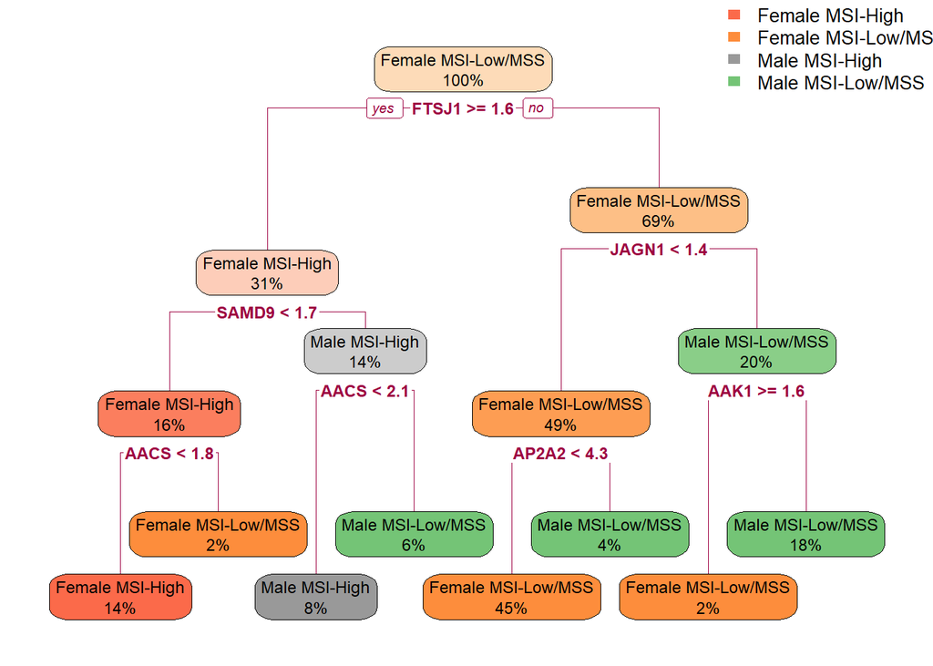

```r
library(rpart)
library(rpart.plot)
library(caret)

# using mean imputation
classColNum <- grep("class",names(train_set_knn))
mismatchColNum <- grep("mismatch",names(train_set_knn))
index <- createDataPartition(train_set_knn$class, p = 0.7, list = FALSE)
train_data <- train_set_knn[ index, -mismatchColNum]
test_data  <- train_set_knn[-index, ]

control <- trainControl(method = "repeatedcv", number = 10)
rpart_fit <- rpart(class ~ ., data = train_data, method = "class",
                   parms = list(split = 'information'), minsplit = 2, minbucket = 1)
#summary(rpart_fit)
rpart.plot(rpart_fit, extra = 100)
```

```r
# filter train_set by the important varaiable
rpart_features_impt <- rpart_fit$variable.importance
train_set_fs_rp <- train_set_knn[, c(which(colnames(train_set_knn) %in%  names(rpart_features_impt)))]
train_set_fs_rp$class <- train_set_knn$class
# train_set_fs_rf[1:5,(ncol(train_set_fs_rf)-5):ncol(train_set_fs_rf)]

classColNum <- grep("class",names(train_set_fs_rp))
mismatchColNum <- grep("mismatch",names(train_set_fs_rp))
set.seed(1)
index <- createDataPartition(train_set_fs_rp$class, p = 0.7, list = FALSE)
train_data <- train_set_fs_rp[ index, ]
test_data  <- train_set_fs_rp[-index, ]

set.seed(1)
ctrl <- trainControl(method = "repeatedcv", number=10, verboseIter=FALSE, sampling=NULL)
model_fs_rp <- train(class~., data=train_data, method = "knn", preProcess = c("scale", "center"), trControl=ctrl )
pred <- predict(model_fs_rp, test_data)
cm_fs_rp <- confusionMatrix(pred, test_data$class)
cm_fs_rp$byClass[7]
```

```
## [1] 1
```

### 3.3.3 Feature Selection (RF)

Random Forest is often used for prediction. However, when looking at feature importances you can get the impression of which variables have the greatest impact on the models. New features can be created from this information, as well as the ability to eliminate features with the appearance of noise, or just to inform one to continue building models [8].

A number of decision trees comprises Random forest. Each decision tree node is a condition of a single feature. This is planned to divide the dataset into two parts with like response values appearing in the same set. ‘Impurity’ is a measure based on the way locally optimal condition is chosen.

```r
library(randomForest)
#---------------------------
# using NDA imputation
#---------------------------
classColNum <- grep("class",names(train_set_knn))
mismatchColNum <- grep("mismatch",names(train_set_knn))
wrapper <- rfe(train_set_knn[,1:classColNum-1],train_set_knn$class, sizes = seq(10,1000,100),
               rfeControl = rfeControl(functions=rfFuncs,method='cv'))
selectVars<- train_set[wrapper$optVariables]
cat(c("The number of features selected by wrapper method is:",length(selectVars),"\n"))
```

```
## The number of features selected by wrapper method is: 610
```

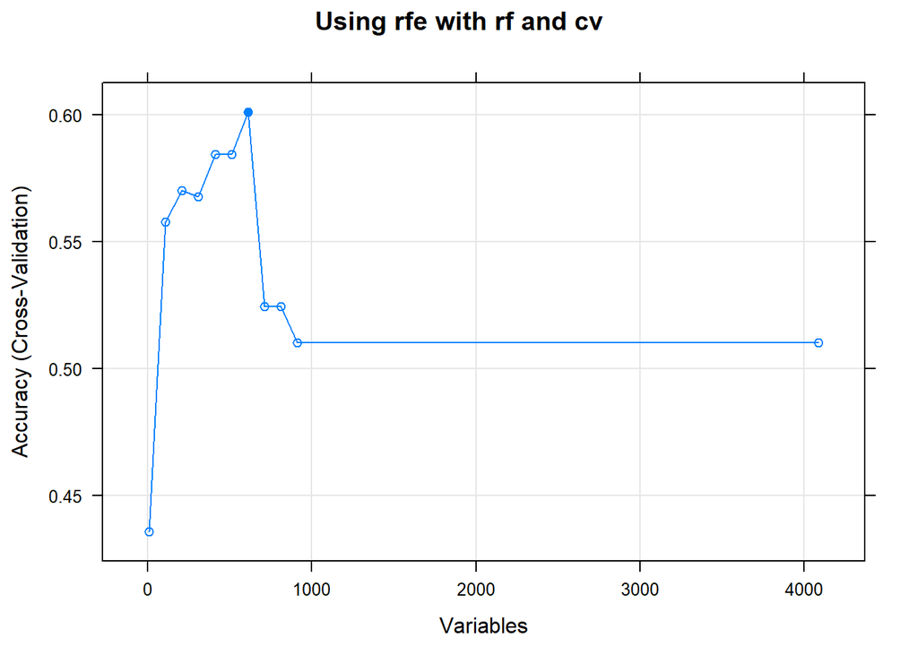

```r
plot(wrapper,type=c('o','g'),main = "Using rfe with rf and cv")
```

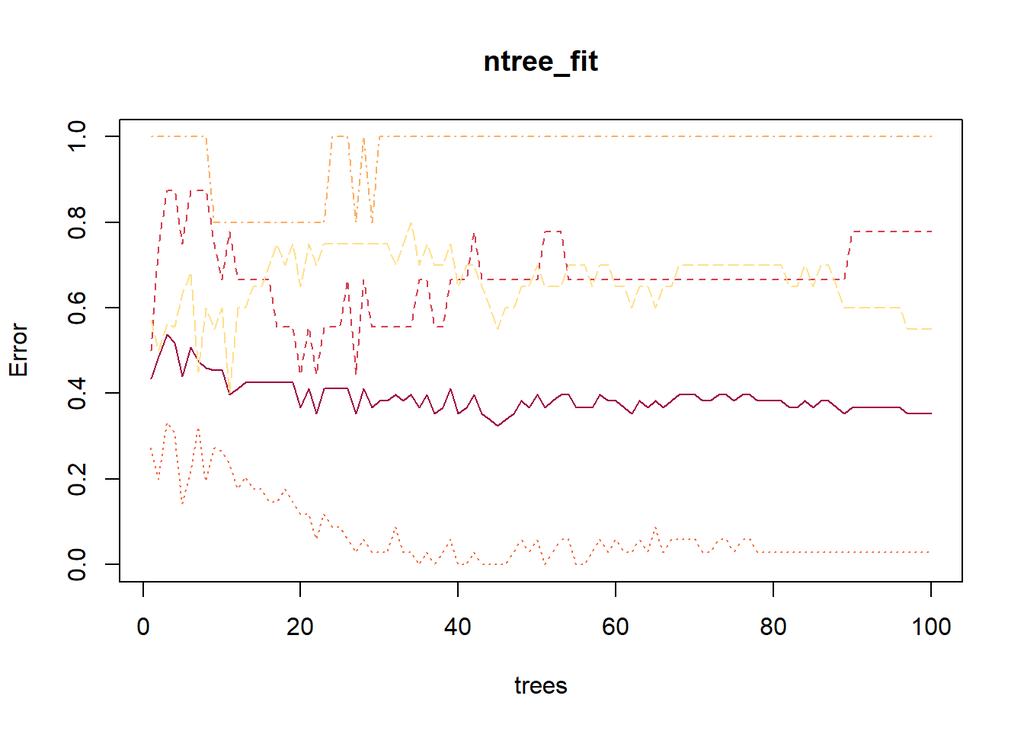

```r
rf_features_impt <- predictors(wrapper)
train_set_fs_rf <- train_set_knn[, rf_features_impt]
train_set_fs_rf$class <- train_set_knn$class
# train_set_fs_rf[1:5,(ncol(train_set_fs_rf)-5):ncol(train_set_fs_rf)]

ntree_fit <-randomForest(class~.,data = train_set_fs_rf, mtry=5,ntree=100)
plot(ntree_fit)
```

```r
classColNum <- grep("class",names(train_set_fs_rf))
mismatchColNum <- grep("mismatch",names(train_set_fs_rf))

set.seed(1)
index <- createDataPartition(train_set_fs_rf$class, p = 0.7, list = FALSE)
train_data <- train_set_fs_rf[ index, ]
test_data  <- train_set_fs_rf[-index, ]

set.seed(1)
ctrl <- trainControl(method = "repeatedcv", number=10, verboseIter=FALSE, sampling=NULL)
model_fs_rf <- train(class~., data=train_data, method = "knn", preProcess = c("scale", "center"), trControl=ctrl )
pred <- predict(model_fs_rf, test_data)
cm_fs_rf <- confusionMatrix(pred, test_data$class)
cm_fs_rf$byClass[7]
```

```
## [1] 1
```

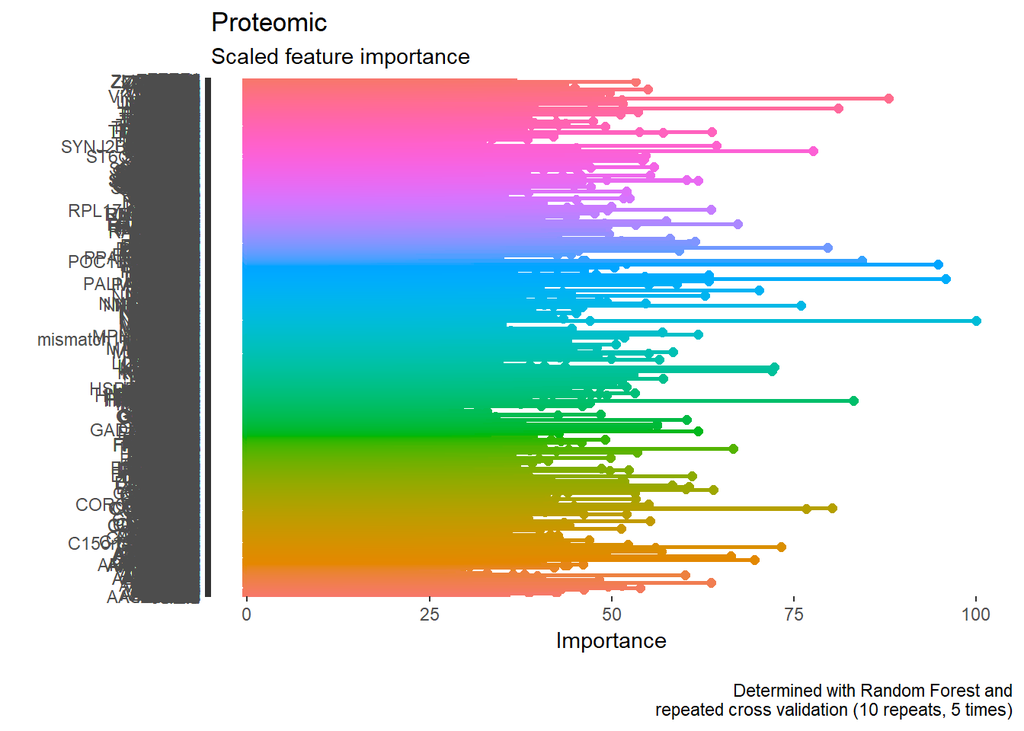

```r
# pretty chart
set.seed(1)
feature_imp <- function(model, title) {
  # estimate variable importance
  importance <- varImp(model, scale = TRUE)

  # prepare dataframes for plotting
  importance_df_1 <- importance$importance
  importance_df_1$group <- rownames(importance_df_1)

  importance_df_2 <- importance_df_1
  importance_df_2$Overall <- 0

  importance_df <- rbind(importance_df_1, importance_df_2)

  plot <- ggplot() +
    geom_point(data = importance_df_1, aes(x = Overall, y = group, color = group), size = 2) +
    geom_path(data = importance_df, aes(x = Overall, y = group, color = group, group = group), size = 1) +
    theme(legend.position = "none") +
    labs(
      x = "Importance",
      y = "",
      title = title,
      subtitle = "Scaled feature importance",
      caption = "\nDetermined with Random Forest and
      repeated cross validation (10 repeats, 5 times)"
    )
  return(plot)

}

rf_fit <- train(class~., data=train_set_knn, method="rf", preProcess= c("scale", "center"))
feature_imp(rf_fit, title = "Proteomic")
```

### 3.3.4 sPLS-DA

Using a single stage process sPLS-DA makes variable selection and classification. To permit variable selection sPLS-DA may be regarded as a limited aspect of sparse PLS. Note that variables are selected in a supervised framework, and only in the X data set. That is, choosing of X-variables done in respect of samples of different classes [10].

The classification performance of sPLS-DA is along the same lines as wrapper and sparse discriminant analysis techniques found in SNP data sets and on the public microarray. Of key importance, sPLS-DA is superior in terms of interpretability of the results via valuable graphical outputs, as well as being is quite competitive in terms of computational efficiency.sPLS-DA is to be found in the R package mixOmics, which is committed to the analysis of large biological datasets [11].

```r
library(mixOmics)
```

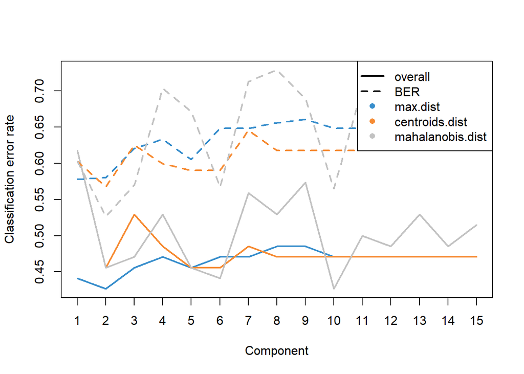

```r
classColNum <- grep("class",names(train_set_knn))
mismatchColNum <- grep("mismatch",names(train_set_knn))
# train_set_knn[1:5,(ncol(train_set_knn)-5):ncol(train_set_knn)]

X<-train_set_knn[, 1:classColNum-1]
Y<-train_set_knn$class

## sPLS-DA function
splsda<-splsda(X,Y,ncomp = 15)

perf_splsda <- perf(splsda, validation = 'loo',progressBar = FALSE, auc = TRUE)

plot(perf_splsda)
```

```r
#choose the number of nComps which at the lowest error rate
nComps <- 2

# Grid of possible keepX values
list.keepX <- seq(10,500,20)
tune_splsda <- tune.splsda(X, Y, ncomp = nComps, validation = 'loo',progressBar = FALSE,test.keepX = list.keepX)

#selected features in comp1 and comp2
tune_splsda$choice.keepX
```

```
## comp1 comp2
##    70    90
```

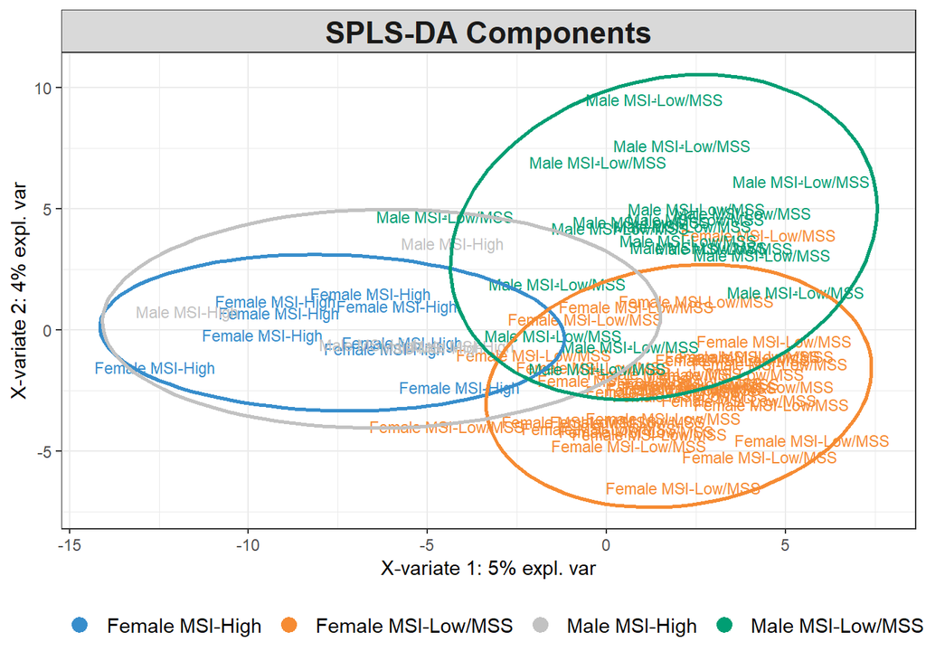

```r
choice.keepX <- tune_splsda$choice.keepX[1:nComps]

## sPLS-DA function
model_fs_splsda <- splsda(X, Y, ncomp = 2, keepX = choice.keepX)

## Plot components
comp1 = 1
comp2 = 2

p1 <- plotIndiv(model_fs_splsda, ind.names = Y,comp = c(comp1, comp2), ellipse = TRUE, legend = TRUE,legend.position = 'bottom', title = 'SPLS-DA Components', style = 'ggplot2', legend.title = NULL)
```

```r
## Keep the selected features of 2 components
selectedFeatures <- unlist(sapply(1:nComps, function(i) rownames(selectVar(model_fs_splsda, comp = i)$value)))
train_set_fs_splsda<-X[,selectedFeatures]
train_set_fs_splsda$class<-Y


classColNum <- grep("class",names(train_set_fs_splsda))
mismatchColNum <- grep("mismatch",names(train_set_fs_splsda))
set.seed(1)
index <- createDataPartition(train_set_fs_splsda$class, p = 0.7, list = FALSE)
train_data <- train_set_fs_splsda[ index, ]
test_data  <- train_set_fs_splsda[-index, ]

set.seed(1)
ctrl <- trainControl(method = "repeatedcv", number=10,verboseIter=FALSE, sampling=NULL)
model_fs_splsda <- train(class~., data=train_data, method = "knn", preProcess = c("scale", "center"), trControl=ctrl )
pred <- predict(model_fs_splsda, test_data)
cm_fs_splsda <- confusionMatrix(pred, test_data$class)
cm_fs_splsda$byClass[7]
```

```
## [1] 0.9444444
```